# Problem Statement

Customers’ leaving credit cards services would lead bank to loss, so the bank wants to analyze the data of customers’ and identify the customers who will leave their credit card services and reason for same – so that bank could improve upon those areas

You as a Data scientist at Thera bank need to come up with a classification model that will help bank improve their services so that customers do not renounce their credit cards

# Data Dictionary:

- CLIENTNUM: Client number. Unique identifier for the customer holding the account
- Attrition_Flag: Internal event (customer activity) variable - if the account is closed then 1 else 0
- Customer_Age: Age in Years
- Gender: Gender of the account holder
- Dependent_count: Number of dependents
- Education_Level: Educational Qualification of the account holder
- Marital_Status: Marital Status of the account holder
- Income_Category: Annual Income Category of the account holder
- Card_Category: Type of Card
- Months_on_book: Period of relationship with the bank
- Total_Relationship_Count: Total no. of products held by the customer
- Months_Inactive_12_mon: No. of months inactive in the last 12 months
- Contacts_Count_12_mon: No. of Contacts in the last 12 months
- Credit_Limit: Credit Limit on the Credit Card
- Total_Revolving_Bal: Total Revolving Balance on the Credit Card
- Avg_Open_To_Buy: Open to Buy Credit Line (Average of last 12 months)
- Total_Amt_Chng_Q4_Q1: Change in Transaction Amount (Q4 over Q1)
- Total_Trans_Amt: Total Transaction Amount (Last 12 months)
- Total_Trans_Ct: Total Transaction Count (Last 12 months)
- Total_Ct_Chng_Q4_Q1: Change in Transaction Count (Q4 over Q1)
- Avg_Utilization_Ratio: Average Card Utilization Ratio

## Index

- Import Libraries and Load data
- Overview of the dataset
- EDA
  - Univariant Analysis
  - BiVariant Analysis
  - Correlation Matrix
- Illustrate the insights based on EDA
- Data Pre-processing
  - Outlier detection
  - Missing value Treatment
  - Prepare data for modeling
  - Feature Engineering
- Split the dataset
- Model building
  - Model Evaluation Criteria
- Logistic Regression
  - Simple Logistic Regression
  - Logistic Regression with Upsampling
  - Logistic Regression with Downsampling
  - Logistic Regression with Upsampling,Regularization
- Model building - Bagging and Boosting
  - Bagging and Boosting
  - Insights from Bagging and Boosting Model Metrics
- Hyperparameter tuning using grid search
  - Decision tree
  - Random Forest
  - Bagging Classifier
  - Ada Boost
  - Gradient Boost
  - XG Boost
  - Metrics Comparision
  - Insights
- Hyperparameter tuning using Random search
  - Decision tree
  - Random Forest
  - Bagging Classifier
  - Ada Boost
  - Gradient Boost
  - XG Boost
  - Metrics Comparision
  - Insights
- Model Performances
- Actionable Insights & Recommendations

## Import Libraries and Load data

```python
import warnings

warnings.filterwarnings("ignore")

# Libraries for reading and manipulating data
import pandas as pd
import numpy as np

# Libaries for data visualization
%matplotlib inline
import matplotlib.pyplot as plt
import seaborn as sns

# Libraries to tune model, get different metric scores, and split data
from sklearn import metrics
from sklearn.model_selection import train_test_split, StratifiedKFold, cross_val_score
from sklearn.preprocessing import StandardScaler
from sklearn.model_selection import GridSearchCV, RandomizedSearchCV


from sklearn.pipeline import Pipeline, make_pipeline
from scipy.stats import randint as sp_randint

#Libraries for model building
from sklearn.linear_model import LogisticRegression
from sklearn.tree import DecisionTreeClassifier
from sklearn.ensemble import (
    AdaBoostClassifier,
    GradientBoostingClassifier,
    RandomForestClassifier,
BaggingClassifier)

from xgboost import XGBClassifier

#Upsampling and Downsampling
from imblearn.over_sampling import SMOTE
from imblearn.under_sampling import TomekLinks
```

```python
!pip install numpy==1.19.3
```

```python
data = pd.read_csv('BankChurners.csv')
```

## Overview of the dataset

```python
data.info()   # print data info
```

```
<class 'pandas.core.frame.DataFrame'>
RangeIndex: 10127 entries, 0 to 10126
Data columns (total 21 columns):
 #   Column                    Non-Null Count  Dtype
---  ------                    --------------  -----
 0   CLIENTNUM                 10127 non-null  int64
 1   Attrition_Flag            10127 non-null  object
 2   Customer_Age              10127 non-null  int64
 3   Gender                    10127 non-null  object
 4   Dependent_count           10127 non-null  int64
 5   Education_Level           10127 non-null  object
 6   Marital_Status            10127 non-null  object
 7   Income_Category           10127 non-null  object
 8   Card_Category             10127 non-null  object
 9   Months_on_book            10127 non-null  int64
 10  Total_Relationship_Count  10127 non-null  int64
 11  Months_Inactive_12_mon    10127 non-null  int64
 12  Contacts_Count_12_mon     10127 non-null  int64
 13  Credit_Limit              10127 non-null  float64
 14  Total_Revolving_Bal       10127 non-null  int64
 15  Avg_Open_To_Buy           10127 non-null  float64
 16  Total_Amt_Chng_Q4_Q1      10127 non-null  float64
 17  Total_Trans_Amt           10127 non-null  int64
 18  Total_Trans_Ct            10127 non-null  int64
 19  Total_Ct_Chng_Q4_Q1       10127 non-null  float64
 20  Avg_Utilization_Ratio     10127 non-null  float64
dtypes: float64(5), int64(10), object(6)
memory usage: 1.6+ MB
```

- No NULL Values in any columns(no missing data)
- There are 21 columns and 10127 rows

```python
data.head()
```

|  | CLIENTNUM | Attrition_Flag | Customer_Age | Gender | Dependent_count | Education_Level | Marital_Status | Income_Category | Card_Category | Months_on_book | ... | Months_Inactive_12_mon | Contacts_Count_12_mon | Credit_Limit | Total_Revolving_Bal | Avg_Open_To_Buy | Total_Amt_Chng_Q4_Q1 | Total_Trans_Amt | Total_Trans_Ct | Total_Ct_Chng_Q4_Q1 | Avg_Utilization_Ratio |
| --- | --- | --- | --- | --- | --- | --- | --- | --- | --- | --- | --- | --- | --- | --- | --- | --- | --- | --- | --- | --- | --- |
| 0 | 768805383 | Existing Customer | 45 | M | 3 | High School | Married | $60K - $80K | Blue | 39 | ... | 1 | 3 | 12691.0 | 777 | 11914.0 | 1.335 | 1144 | 42 | 1.625 | 0.061 |
| 1 | 818770008 | Existing Customer | 49 | F | 5 | Graduate | Single | Less than $40K | Blue | 44 | ... | 1 | 2 | 8256.0 | 864 | 7392.0 | 1.541 | 1291 | 33 | 3.714 | 0.105 |
| 2 | 713982108 | Existing Customer | 51 | M | 3 | Graduate | Married | $80K - $120K | Blue | 36 | ... | 1 | 0 | 3418.0 | 0 | 3418.0 | 2.594 | 1887 | 20 | 2.333 | 0.000 |
| 3 | 769911858 | Existing Customer | 40 | F | 4 | High School | Unknown | Less than $40K | Blue | 34 | ... | 4 | 1 | 3313.0 | 2517 | 796.0 | 1.405 | 1171 | 20 | 2.333 | 0.760 |
| 4 | 709106358 | Existing Customer | 40 | M | 3 | Uneducated | Married | $60K - $80K | Blue | 21 | ... | 1 | 0 | 4716.0 | 0 | 4716.0 | 2.175 | 816 | 28 | 2.500 | 0.000 |

5 rows × 21 columns

```python
data.describe()
```

|  | CLIENTNUM | Customer_Age | Dependent_count | Months_on_book | Total_Relationship_Count | Months_Inactive_12_mon | Contacts_Count_12_mon | Credit_Limit | Total_Revolving_Bal | Avg_Open_To_Buy | Total_Amt_Chng_Q4_Q1 | Total_Trans_Amt | Total_Trans_Ct | Total_Ct_Chng_Q4_Q1 | Avg_Utilization_Ratio |
| --- | --- | --- | --- | --- | --- | --- | --- | --- | --- | --- | --- | --- | --- | --- | --- |
| count | 1.012700e+04 | 10127.000000 | 10127.000000 | 10127.000000 | 10127.000000 | 10127.000000 | 10127.000000 | 10127.000000 | 10127.000000 | 10127.000000 | 10127.000000 | 10127.000000 | 10127.000000 | 10127.000000 | 10127.000000 |
| mean | 7.391776e+08 | 46.325960 | 2.346203 | 35.928409 | 3.812580 | 2.341167 | 2.455317 | 8631.953698 | 1162.814061 | 7469.139637 | 0.759941 | 4404.086304 | 64.858695 | 0.712222 | 0.274894 |
| std | 3.690378e+07 | 8.016814 | 1.298908 | 7.986416 | 1.554408 | 1.010622 | 1.106225 | 9088.776650 | 814.987335 | 9090.685324 | 0.219207 | 3397.129254 | 23.472570 | 0.238086 | 0.275691 |
| min | 7.080821e+08 | 26.000000 | 0.000000 | 13.000000 | 1.000000 | 0.000000 | 0.000000 | 1438.300000 | 0.000000 | 3.000000 | 0.000000 | 510.000000 | 10.000000 | 0.000000 | 0.000000 |
| 25% | 7.130368e+08 | 41.000000 | 1.000000 | 31.000000 | 3.000000 | 2.000000 | 2.000000 | 2555.000000 | 359.000000 | 1324.500000 | 0.631000 | 2155.500000 | 45.000000 | 0.582000 | 0.023000 |
| 50% | 7.179264e+08 | 46.000000 | 2.000000 | 36.000000 | 4.000000 | 2.000000 | 2.000000 | 4549.000000 | 1276.000000 | 3474.000000 | 0.736000 | 3899.000000 | 67.000000 | 0.702000 | 0.176000 |
| 75% | 7.731435e+08 | 52.000000 | 3.000000 | 40.000000 | 5.000000 | 3.000000 | 3.000000 | 11067.500000 | 1784.000000 | 9859.000000 | 0.859000 | 4741.000000 | 81.000000 | 0.818000 | 0.503000 |
| max | 8.283431e+08 | 73.000000 | 5.000000 | 56.000000 | 6.000000 | 6.000000 | 6.000000 | 34516.000000 | 2517.000000 | 34516.000000 | 3.397000 | 18484.000000 | 139.000000 | 3.714000 | 0.999000 |

```python
data.columns[data.dtypes=='object']  # see the columns of object type
```

```
Index(['Attrition_Flag', 'Gender', 'Education_Level', 'Marital_Status',
       'Income_Category', 'Card_Category'],
      dtype='object')
```

```python
# check value counts for each categorical feature.

category_col = ['Attrition_Flag', 'Gender', 'Education_Level', 'Marital_Status',
       'Income_Category', 'Card_Category']
for col in category_col:
    print('---------------------------------')
    print(data[col].value_counts())
    print('---------------------------------')
```

```
---------------------------------
Existing Customer    8500
Attrited Customer    1627
Name: Attrition_Flag, dtype: int64
---------------------------------
---------------------------------
F    5358
M    4769
Name: Gender, dtype: int64
---------------------------------
---------------------------------
Graduate         3128
High School      2013
Unknown          1519
Uneducated       1487
College          1013
Post-Graduate     516
Doctorate         451
Name: Education_Level, dtype: int64
---------------------------------
---------------------------------
Married     4687
Single      3943
Unknown      749
Divorced     748
Name: Marital_Status, dtype: int64
---------------------------------
---------------------------------
Less than $40K    3561
$40K - $60K       1790
$80K - $120K      1535
$60K - $80K       1402
Unknown           1112
$120K +            727
Name: Income_Category, dtype: int64
---------------------------------
---------------------------------
Blue        9436
Silver       555
Gold         116
Platinum      20
Name: Card_Category, dtype: int64
---------------------------------
```

**Check missing values.**

```python
data.isnull().sum()  # check null
```

```
CLIENTNUM                   0
Attrition_Flag              0
Customer_Age                0
Gender                      0
Dependent_count             0
Education_Level             0
Marital_Status              0
Income_Category             0
Card_Category               0
Months_on_book              0
Total_Relationship_Count    0
Months_Inactive_12_mon      0
Contacts_Count_12_mon       0
Credit_Limit                0
Total_Revolving_Bal         0
Avg_Open_To_Buy             0
Total_Amt_Chng_Q4_Q1        0
Total_Trans_Amt             0
Total_Trans_Ct              0
Total_Ct_Chng_Q4_Q1         0
Avg_Utilization_Ratio       0
dtype: int64
```

Go to index

## EDA

**Univariate analysis - Bivariate analysis - Use appropriate visualizations to identify the patterns and insights - Any other exploratory deep dive** 6M

### Univariant analysis

```python
# For Univariant Analysis of Numerical columns,  Boxplot and Histograms are plotted.
# Histogram is used to study distribution and central tendency.
# Boxplot is used to understand the outliers and quantiles.

def boxplot_histogram(feature, figsize=(15,10), bins=None):
    '''plots boxplot and histogram for given feature
    feature: 1-d feature array
    figsize: size of the figure
    bins: No of bins deault:None/auto'''
    f2, (ax_box2, ax_hist2) = plt.subplots(
        nrows=2,  # Number of rows of the subplot grid= 2
        sharex=True,  # x-axis will be shared among all subplots
        gridspec_kw={"height_ratios": (0.25, 0.75)},
        figsize=figsize,
    )  # creating the 2 subplots
    sns.boxplot(
        feature, ax=ax_box2, showmeans=True, color="violet"
    )  # boxplot will be created and a star will indicate the mean value of the column
    sns.distplot(
        feature, kde=F, ax=ax_hist2, bins=bins, palette="winter"
    ) if bins else sns.distplot(
        feature, kde=True, ax=ax_hist2
    )  # For histogram
    ax_hist2.axvline(
        np.mean(feature), color="green", linestyle="--"
    )  # Add mean to the histogram
    ax_hist2.axvline(
        np.median(feature), color="black", linestyle="-"
    )  # Add median to the histogram
```

```python
# Print all column names of datatype integer

for feature in data.iloc[:,1:].columns:
    if(data[feature].dtypes=='int64'):
        print(feature)

print('--------------------------------')
for feature in data.iloc[:,1:].columns:
    if(data[feature].dtypes=='float64'):
        print(feature)
```

```
Customer_Age
Dependent_count
Months_on_book
Total_Relationship_Count
Months_Inactive_12_mon
Contacts_Count_12_mon
Total_Revolving_Bal
Total_Trans_Amt
Total_Trans_Ct
--------------------------------
Credit_Limit
Avg_Open_To_Buy
Total_Amt_Chng_Q4_Q1
Total_Ct_Chng_Q4_Q1
Avg_Utilization_Ratio
```

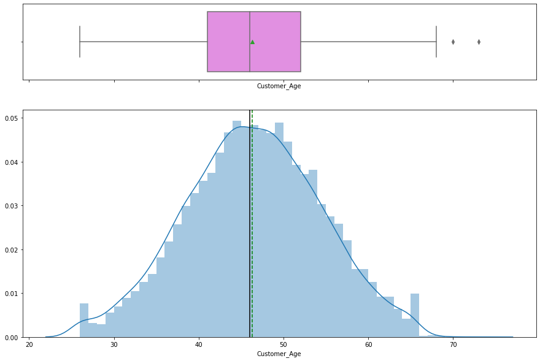

```python
boxplot_histogram(data['Customer_Age'])
```

- Customer age has fairly normal distribution with approx same mean and median.
- There are two outliers shown in the boxplots.

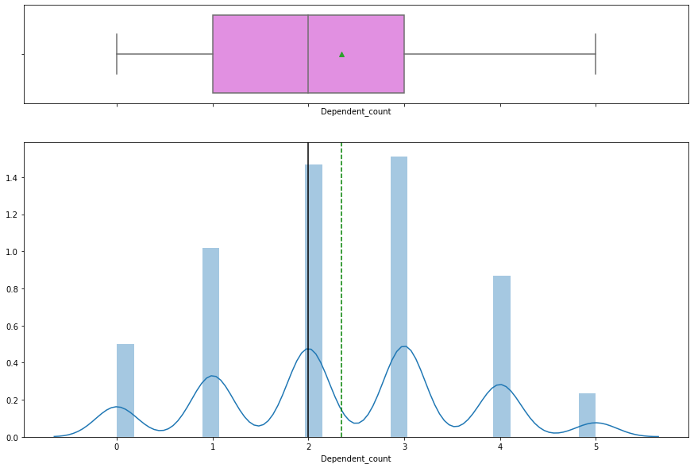

```python
boxplot_histogram(data['Dependent_count'])
```

- There are more number of customers whoc have dependent count as 3. Number of customers with Dependent_count= 2 is also approx same as Dependent_count= 3

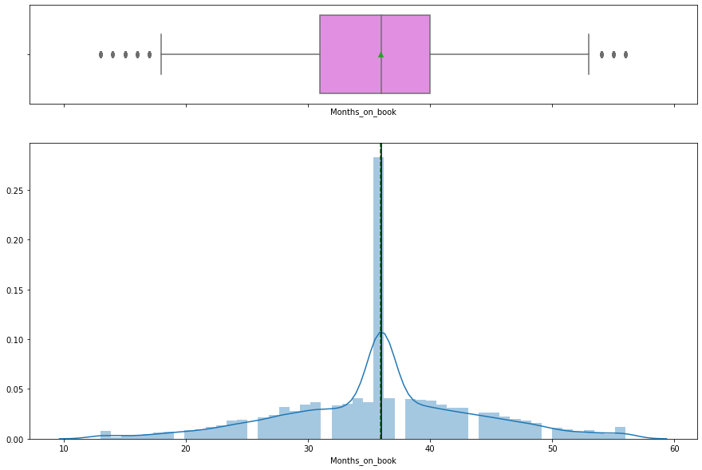

```python
boxplot_histogram(data['Months_on_book'])
```

- There are more number of customers around median and mean of Months_on_book
- There are few outliers both on left and right.

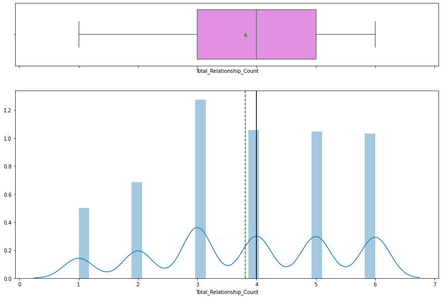

```python
boxplot_histogram(data['Total_Relationship_Count'])
```

Total_Relationship_Count: Total no. of products held by the customer

Number of Customer with 3 products are more.

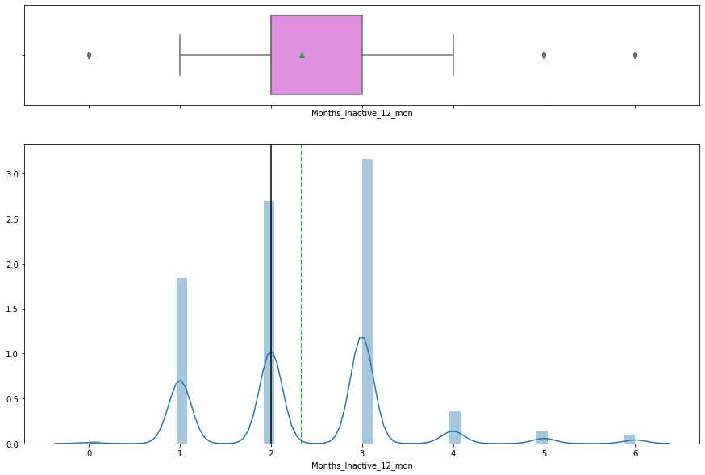

```python
boxplot_histogram(data['Months_Inactive_12_mon'])
```

- Max number of users with Months_inactive_12_mon is 3 months.

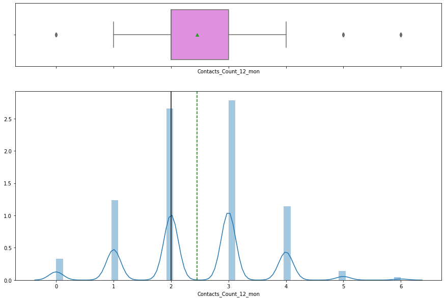

```python
boxplot_histogram(data['Contacts_Count_12_mon'])
```

- Majority of customers contacted 2-3 times in last 12 months.

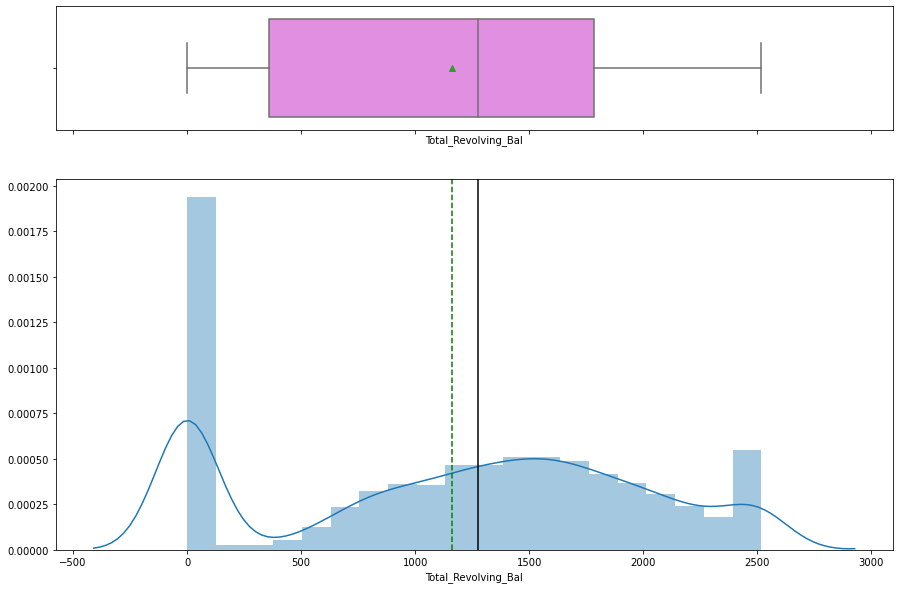

```python
boxplot_histogram(data['Total_Revolving_Bal'])
```

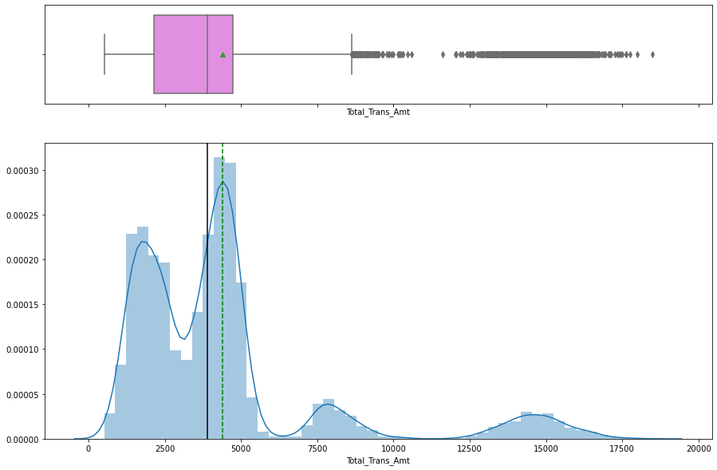

```python
boxplot_histogram(data['Total_Trans_Amt'])
```

- There are many outliers in Total_Trans_Amt but these outliers cannot be removed or modified as we want the model to learn from these datapoints.

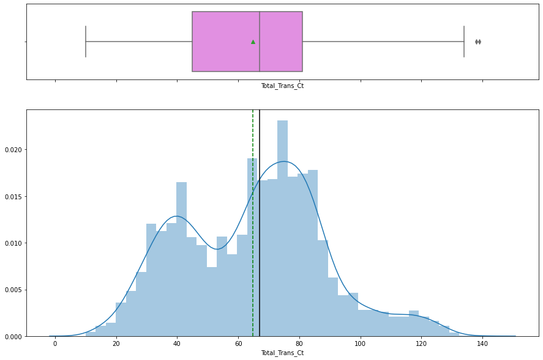

```python
boxplot_histogram(data['Total_Trans_Ct'])
```

- Number of transactions distribution has two peaks one around 40 and other around 80.
- There are two outliers on right but they are not very far from quantile so looks like they are valid points.

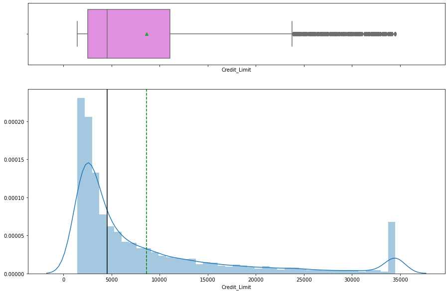

```python
boxplot_histogram(data['Credit_Limit'])
```

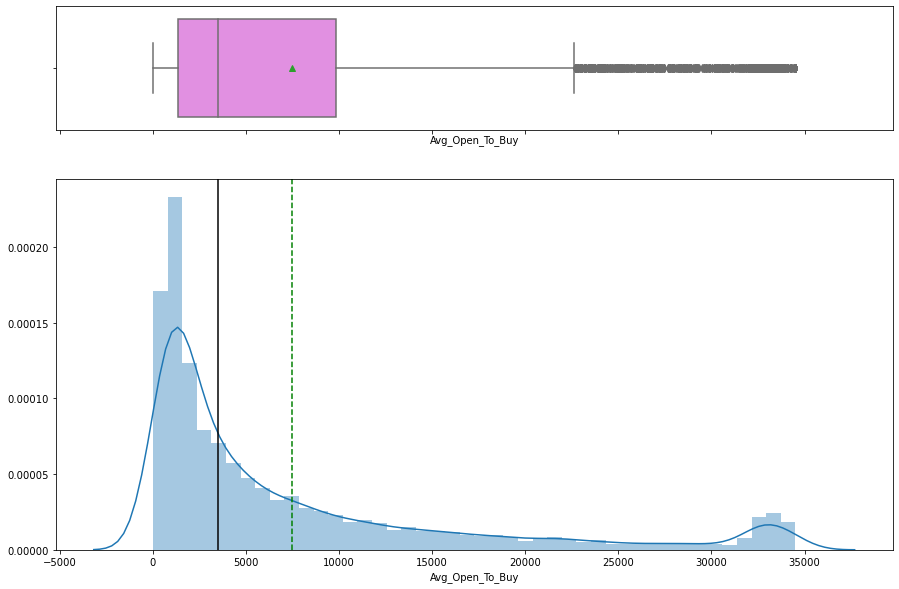

```python
boxplot_histogram(data['Avg_Open_To_Buy'])
```

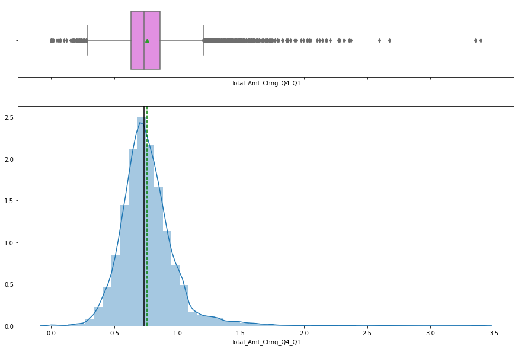

```python
boxplot_histogram(data['Total_Amt_Chng_Q4_Q1'])
```

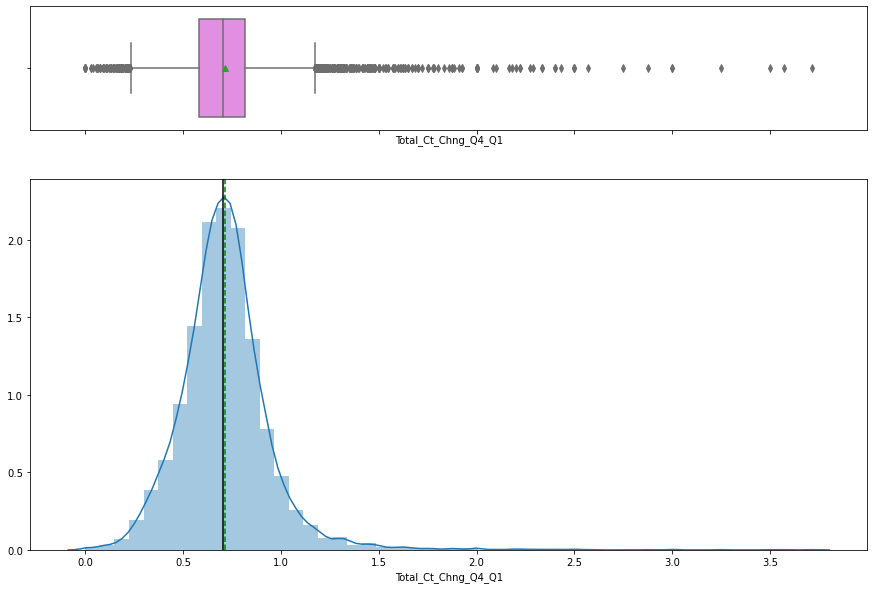

```python
boxplot_histogram(data['Total_Ct_Chng_Q4_Q1'])
```

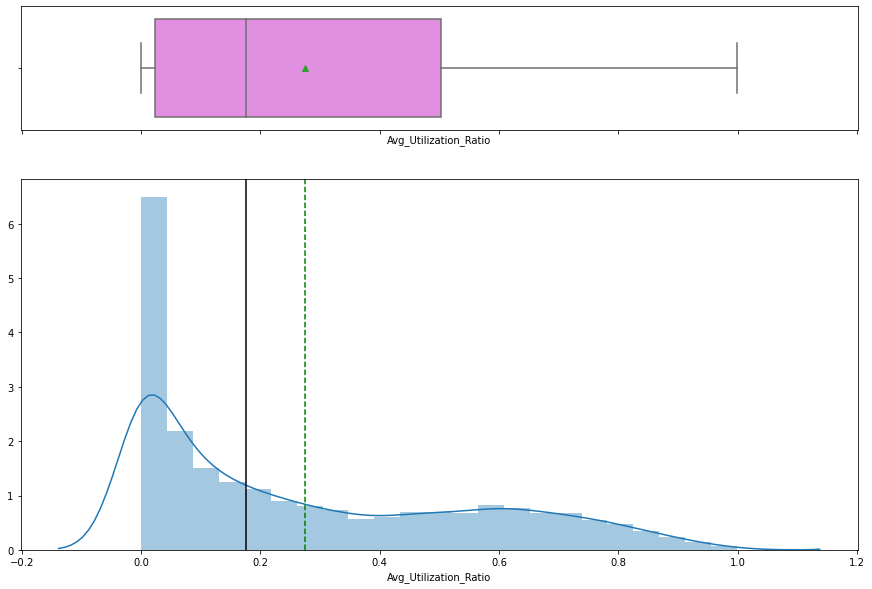

```python
boxplot_histogram(data['Avg_Utilization_Ratio'])
```

```python
# Generate counts plot graphs for categorical features in the data.
def count_plots(feature):
    '''Plots count_plot for category variables
    feature: 1-d feature array'''
    plt.figure(figsize=(10,5))
    ax = sns.countplot(feature)
    total = len(feature)  # length of the column
    for p in ax.patches:
        percentage = "{:.1f}%".format(
            100 * p.get_height() / total
        )  # percentage of each class of the category
        x = p.get_x() + p.get_width() / 2 - 0.1  # width of the plot
        y = p.get_y() + p.get_height()  # hieght of the plot
        ax.annotate(percentage, (x, y), size=14)  # annotate the percantage

    plt.show()  # show the plot
```

```python
# print all column names of datatype object
for feature in data.iloc[:,1:].columns:
    if(data[feature].dtypes=='object'):
        print(feature)
```

```
Attrition_Flag
Gender
Education_Level
Marital_Status
Income_Category
Card_Category
```

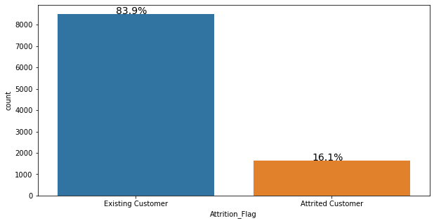

```python
count_plots(data['Attrition_Flag'])
```

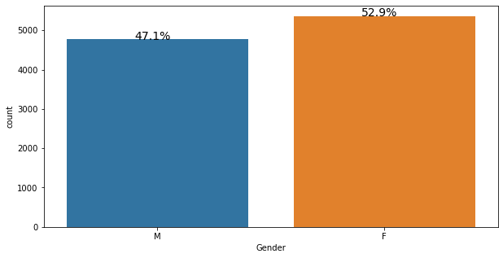

```python
count_plots(data['Gender'])
```

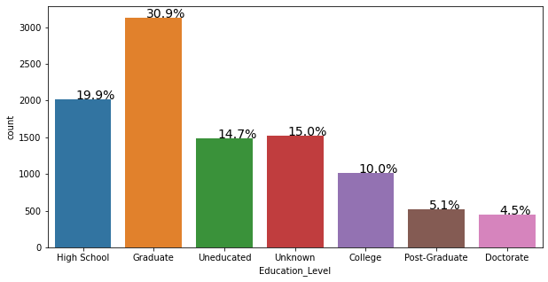

```python
count_plots(data['Education_Level'])
```

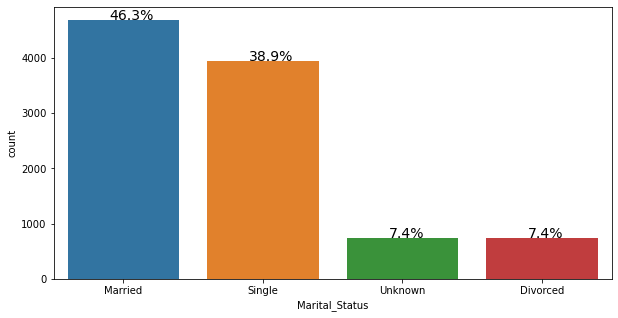

```python
count_plots(data['Marital_Status'])
```

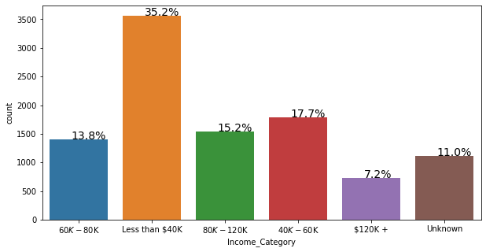

```python
count_plots(data['Income_Category'])
```

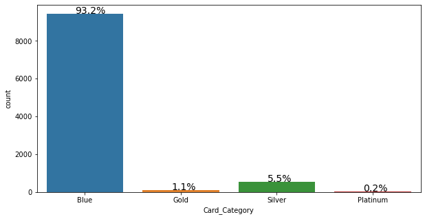

```python
count_plots(data['Card_Category'])
```

### Insights from Count plots

- 16% of Customers left their credit card services.
- Female customers are more.
- Majority of customers are graduates, Married.
- Popular income category is less than 40k.
- Blue type card is famous among the Card_categories.

## BiVariant Analysis

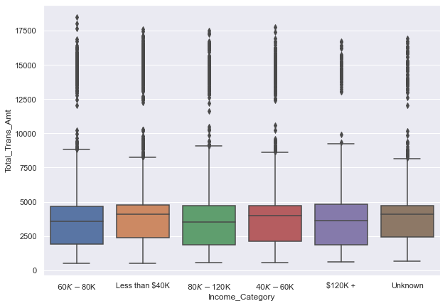

```python
sns.set(rc={"figure.figsize": (10, 7)})
sns.boxplot(y="Total_Trans_Amt", x="Income_Category", data=data, orient="vertical")
plt.show()

#
```

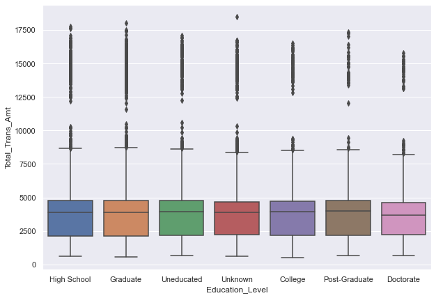

```python
sns.set(rc={"figure.figsize": (10, 7)})
sns.boxplot(y="Total_Trans_Amt", x="Education_Level", data=data, orient="vertical")
plt.show()
```

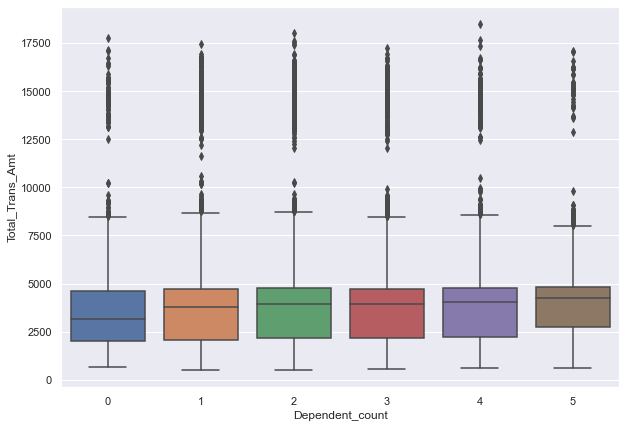

```python
sns.set(rc={"figure.figsize": (10, 7)})
sns.boxplot(y="Total_Trans_Amt", x="Dependent_count", data=data, orient="vertical")
plt.show()
```

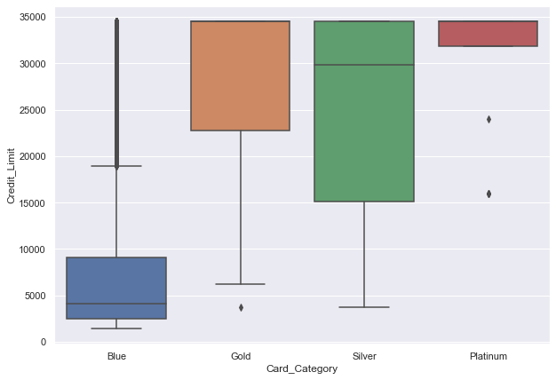

```python
sns.set(rc={"figure.figsize": (10, 7)})
sns.boxplot(y="Credit_Limit", x="Card_Category", data=data, orient="vertical")
plt.show()
```

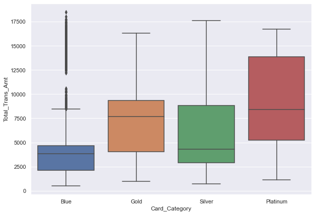

```python
sns.set(rc={"figure.figsize": (10, 7)})
sns.boxplot(y="Total_Trans_Amt", x="Card_Category", data=data, orient="vertical")
plt.show()
```

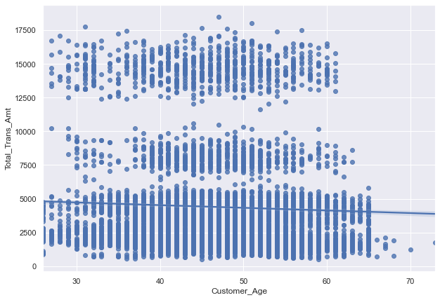

```python
sns.regplot(y=data.Total_Trans_Amt, x=data.Customer_Age)
#Customer_Age,Credit_Limit
plt.show()
```

```python
# Customers with age above 65 have very minimum Total_Trans_amt
```

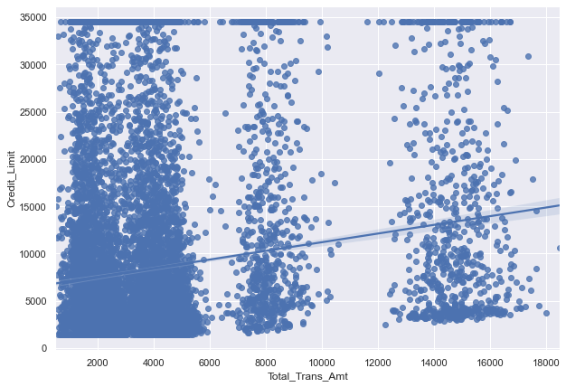

```python
sns.regplot(y=data.Credit_Limit, x=data.Total_Trans_Amt)
plt.show()
```

```python
# The pattern shows there are three different bands of customers with different range of Total_Trans_Amt
```

```python
data.dtypes
```

```
CLIENTNUM                     int64
Attrition_Flag               object
Customer_Age                  int64
Gender                       object
Dependent_count               int64
Education_Level              object
Marital_Status               object
Income_Category              object
Card_Category                object
Months_on_book                int64
Total_Relationship_Count      int64
Months_Inactive_12_mon        int64
Contacts_Count_12_mon         int64
Credit_Limit                float64
Total_Revolving_Bal           int64
Avg_Open_To_Buy             float64
Total_Amt_Chng_Q4_Q1        float64
Total_Trans_Amt               int64
Total_Trans_Ct                int64
Total_Ct_Chng_Q4_Q1         float64
Avg_Utilization_Ratio       float64
dtype: object
```

[figure not shown]

```python
cols = data[
    [
        "Credit_Limit",
        "Total_Amt_Chng_Q4_Q1",
        "Total_Trans_Amt",
        "Customer_Age",
    ]
].columns.tolist()
plt.figure(figsize=(10, 10))

for i, variable in enumerate(cols):
    plt.subplot(3, 2, i + 1)
    sns.boxplot(data["Attrition_Flag"], data[variable])
    plt.tight_layout()
    plt.title(variable)
plt.show()
```

### Insights

- Total_Trans_Amt is more for Existing Customers when compared to Attrited Customers.
- Age range of customers is almost same for Existing customers and Attrited customers.
- Total_Trans_Amt is more for Existing customers when compared to Attrited customers.

```python
### Function to plot stacked bar charts for categorical columns
def stacked_plot(x):
    sns.set(palette="nipy_spectral")
    tab1 = pd.crosstab(x, data["Attrition_Flag"], margins=True)
    print(tab1)
    print("-" * 120)
    tab = pd.crosstab(x, data["Attrition_Flag"], normalize="index")
    tab.plot(kind="bar", stacked=True, figsize=(10, 5))
    plt.legend(loc="lower left", frameon=False)
    plt.legend(loc="upper left", bbox_to_anchor=(1, 1))
    plt.show()
```

```
Attrition_Flag   Attrited Customer  Existing Customer    All
Education_Level
College                        154                859   1013
Doctorate                       95                356    451
Graduate                       487               2641   3128
High School                    306               1707   2013
Post-Graduate                   92                424    516
Uneducated                     237               1250   1487
Unknown                        256               1263   1519
All                           1627               8500  10127
------------------------------------------------------------------------------------------------------------------------
```

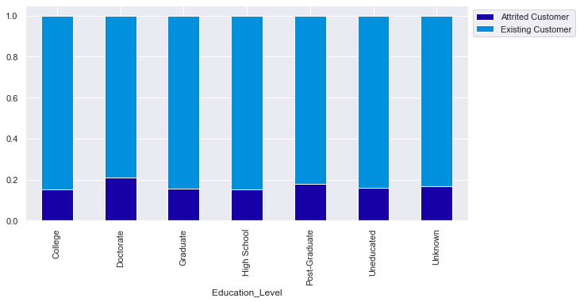

```python
stacked_plot(data['Education_Level'])
```

```python
#Customers with  Education_level as Doctorate Degree are more in Attrited_Customers.
```

```
Attrition_Flag   Attrited Customer  Existing Customer    All
Income_Category
$120K +                        126                601    727
$40K - $60K                    271               1519   1790
$60K - $80K                    189               1213   1402
$80K - $120K                   242               1293   1535
Less than $40K                 612               2949   3561
Unknown                        187                925   1112
All                           1627               8500  10127
------------------------------------------------------------------------------------------------------------------------
```

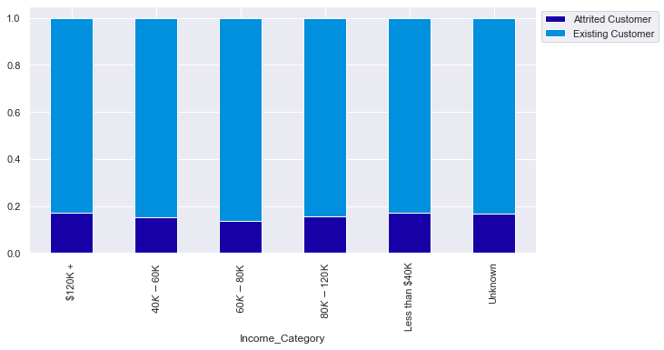

```python
stacked_plot(data['Income_Category'])
```

```python
# Number of Attrited_Customers are almost same in all Income Categories.
```

```
Attrition_Flag  Attrited Customer  Existing Customer    All
Card_Category
Blue                         1519               7917   9436
Gold                           21                 95    116
Platinum                        5                 15     20
Silver                         82                473    555
All                          1627               8500  10127
------------------------------------------------------------------------------------------------------------------------
```

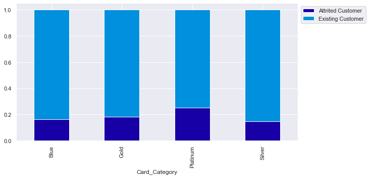

```python
stacked_plot(data['Card_Category'])
```

```python
# Attrition is more in Platinum card category.
```

```
Attrition_Flag   Attrited Customer  Existing Customer    All
Dependent_count
0                              135                769    904
1                              269               1569   1838
2                              417               2238   2655
3                              482               2250   2732
4                              260               1314   1574
5                               64                360    424
All                           1627               8500  10127
------------------------------------------------------------------------------------------------------------------------
```

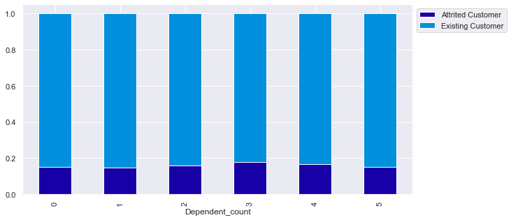

```python
stacked_plot(data['Dependent_count'])
```

Go to index